# Class 14 Marketing Mix Modeling

Author

Affiliation

Dr Wei Miao

UCL School of Management

Published

November 15, 2023

# 1 Marketing Mix Modeling

## 1.1 Marketing Mix

[figure not shown]

## 1.2 What is Marketing Mix Modeling

### 1.2.1 Marketing Mix Modeling

Marketing Mix Modeling (MMM) is the use of statistical analysis to **estimate the causal impact** of various **marketing** **mix variables (**especially **pricing** and **promotions)** on **sales**.

- **Core idea**: find an appropriate statistical model that can characterize the DGP between sales and various marketing mix variables. After estimating the causal effect of each variable, we are able to do budget optimization.

$$sales_t = \beta_0 + \beta_1Price_t + \beta_2Ads_t + \beta_3Channels_t + ... + \epsilon_t$$

- > [Project scope for Buberry in previous years] “Marketing Mix Modelling is a holistic modelling technique that helps to estimate the effectiveness of marketing efforts. It enables the measurement of business drivers and provides insights to the stakeholders to make decisions regarding budget allocation. Bayesian Methods are currently regarded as one of the most advanced techniques to build these models. We already have Bayesian MMM models in place for some regions, and as part of this project, we would want to explore Hierarchical Bayesian MMM model for an easier expansion to other regions.”

# 2 Steps to Build MMM

## 2.1 Phase 1: Data Collection

We need to think about which marketing mix variables are likely affect your sales?

- Channels for selling the products (online, offline, different locations)
- Channels for advertising the product (TV, social media, search engine, influencer marketing, etc.)
- Promotional activities in each period

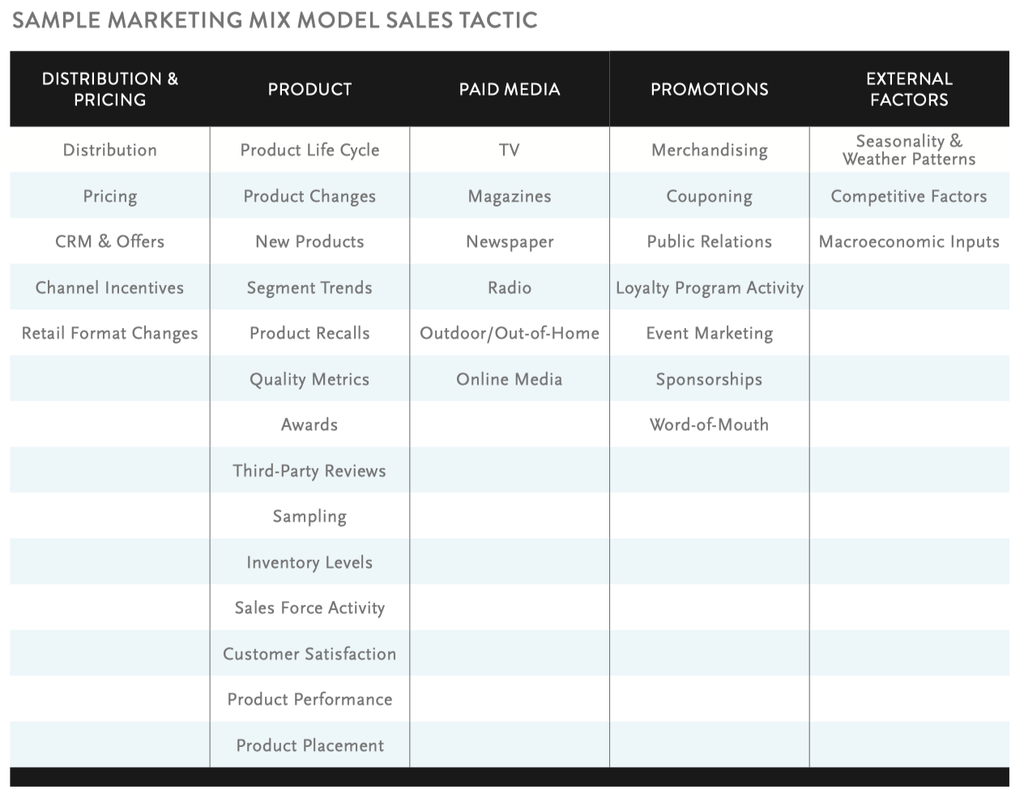

## 2.2 Phase 2: Modeling Considerations (Non-linear Effects)

**What functional forms and specifications to use for each variable?**

*Case 1*: Are [diminishing returns](https://www.investopedia.com/terms/l/lawofdiminishingmarginalreturn.asp) or any nonlinear effects expected on the variable?

- e.g., **advertising saturation**: Increasing the amount of advertising increases the percentage of the audience reached by the advertising, hence increasing demand, but a linear increase in the advertising exposure doesn’t have a similar linear effect on demand. Typically each incremental amount of advertising causes a progressively lesser effect on demand increase.

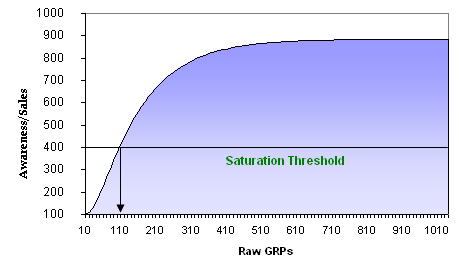

Ads Saturation (source: Wiki)

## 2.3 Phase 2: Modelling Considerations (AdStock Analysis)

*Case 2*: Advertising builds up product awareness among consumers. We can model the current awareness level as a stock variable.

- Without new exposures, the stock of past ads eventually decay to zero
- New ads increase awareness on top of the current stock level
- Mathematically, we can model the ads stock as follows:

$$Adstock_t=NewAds_t+\lambda Adstock_{t-1}, \quad t=1, \ldots, n$$

- $\lambda$ depends on the industry, with a half-life range of around 7– 12 weeks.

```r
# for example, in R, we can mutate Adstock as follow:
data_sales <- data_sales %>%
  mutate(Adstock = NewAds + lag(Adstock) * 0.5 )
```

## 2.4 Phase 3: Model-Based Marketing Mix Optimization

The estimates from the MMM need to eventually address the profit maximization problem.

- The MMM model will produce a host of outputs that measure how each marketing mix variable affects sales.
- We can then use the outputs to compute optimal levels of marketing mix variables for profit maximization (or other business objectives that align with the company’s marketing strategy).

## 2.5 Toy Example: Optimal Pricing to Maximize Profit

- We can utilize the outputs to compute the optimal pricing[^1]
  $$sales_t = 1000 - 20 * Price_t + 0.1 * Adstock_t+ \epsilon_t$$
- Then we know, conditional on $X_t$, the total revenue would be
  $$revenue = Price *sales = Price * (1000 - 20 Price_t + 0.1 Adstock_t)$$
- We can derive the optimal price to maximize revenue.
  $$\partial revenue/\partial price = (1000 - 20 Price_t + 0.1 Adstock_t) - 20 Price = 0$$
- The optimal price that can maximize the revenue/profit is $\frac{1000 + 0.1 Adstock_t}{40}$
  - There is an optimal price to set at each ads level. The higher ads spending, the higher price we can charge customers.

## 2.6 After-class

- [A complete guide to Marketing Mix Modeling](https://www.latentview.com/marketing-mix-modeling/)
- [Bayesian Marketing Mix Modeling](https://towardsdatascience.com/understanding-bayesian-marketing-mix-modeling-a-deep-dive-into-prior-specifications-af400adb836e)

## Footnotes

[^1]: In term 2’s Operations Analytics module, you will learn how to find the optimal pricing, given the estimated marketing mix model.